fossil

# A mutation predictor benchmark, dug back up.

Martelotto and colleagues scored 15 mutation effect predictors, and 11,253 ways of combining them, on 989 cancer mutations whose effect is known. Their statistics code was never shared. We rebuilt it from the paper as the package mutbench and reran it on their own spreadsheet.

See every resultSee the tables

## Fig. 1

Fig. 1. Clustering of the calls of the 15 predictors (A, C) and kappa of each pair (B, D), for all 3,591 SNVs and the 1,699 not in COSMIC. Ours: our calls, kappa colours and dendrograms; the SNVs of our heat map are sorted by their calls, not clustered.

Agrees

Published

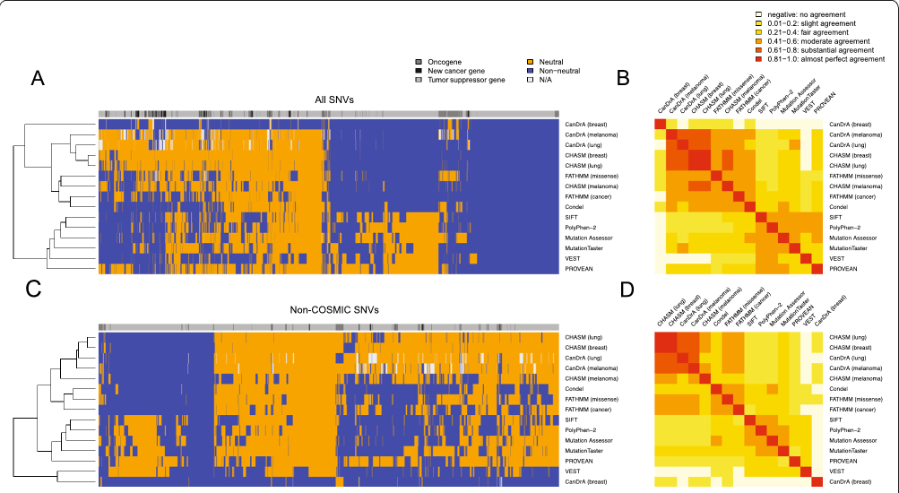

Our run

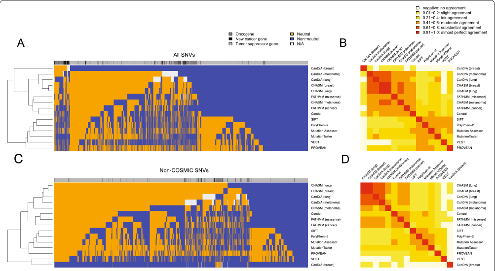

**Fig. 1A, clustering of the calls of all 3,591 SNVs (clades, join heights, row shares)**

71 of 71 values, Agrees

**Fig. 1B, kappa of each pair of predictors, all SNVs (cell colours)**

225 of 225 values, Agrees

**Fig. 1C, clustering of the calls of the 1,699 non-COSMIC SNVs**

71 of 71 values, Agrees

**Fig. 1D, kappa of each pair of predictors, non-COSMIC SNVs (cell colours)**

225 of 225 values, Agrees

## Fig. 2

Fig. 2. Accuracy, sensitivity, specificity, PPV, NPV and composite score of each predictor, on the 989 labelled SNVs (A) and the 297 not in COSMIC (B), with bootstrap 95% intervals.

Agrees

Published

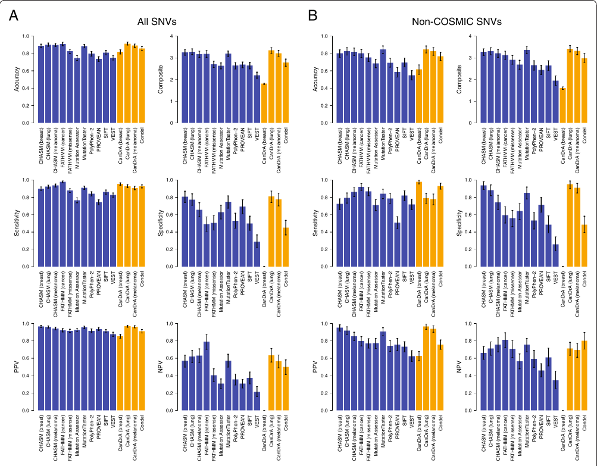

Our run

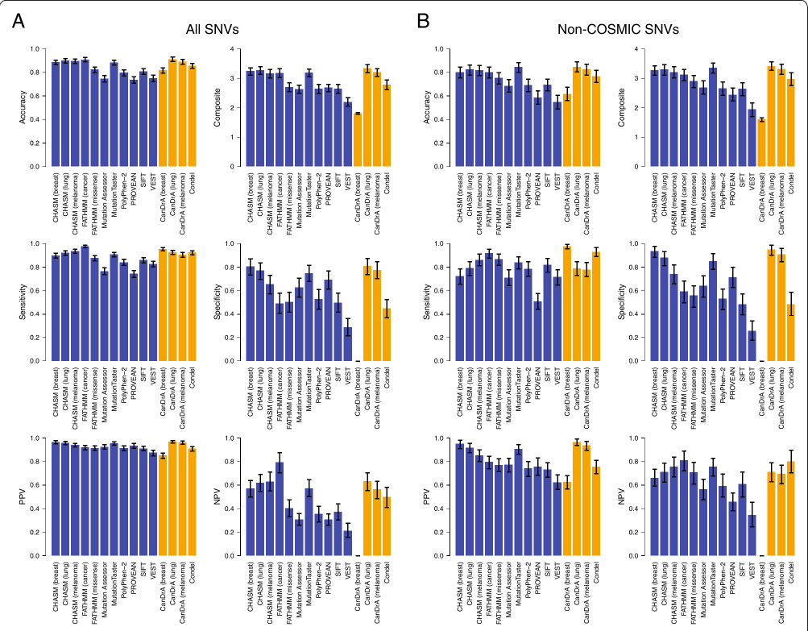

**Fig. 2A, performance on the 989 labelled SNVs (bars)**

90 of 90 values, Agrees

**Fig. 2A, error bars**

176 of 176 values, Agrees

**Fig. 2B, performance on the 297 non-COSMIC SNVs (bars)**

90 of 90 values, Agrees

**Fig. 2B, error bars**

176 of 176 values, Agrees

## Fig. 3

Fig. 3. The top five combinations by composite score in subset 1 and subset 2, against the best single and meta-predictor; stars and triangles mark significant gains in composite score and NPV. Ours: our top five, named in the legend.

Partly agrees

Published

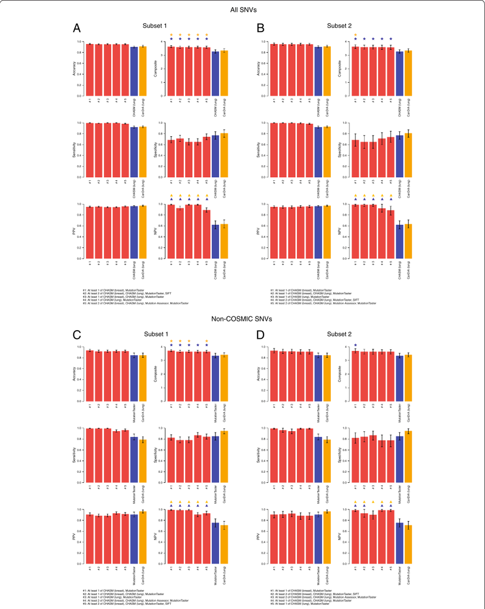

Our run

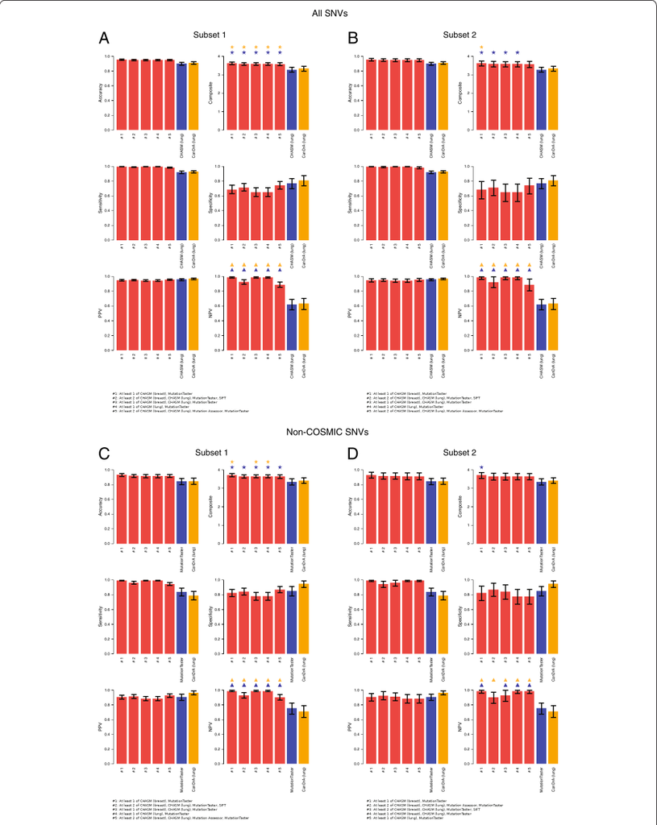

**Fig. 3A, top five combinations by composite score, all SNVs, subset 1 (names, bars, error bars, significance marks)**

151 of 151 values, Agrees

**Fig. 3B, top five combinations by composite score, all SNVs, subset 2 (names, bars, error bars, significance marks)**

147 of 151 values, Partly agrees

**Fig. 3C, top five combinations by composite score, non-COSMIC SNVs, subset 1 (names, bars, error bars, significance marks)**

144 of 151 values, Partly agrees

**Fig. 3D, top five combinations by composite score, non-COSMIC SNVs, subset 2 (names, bars, error bars, significance marks)**

144 of 151 values, Partly agrees

Rankings and counts over 11,253 combinations depend on the random splits: neighbours in the ranking differ by less than the Monte Carlo error, so another set of splits reorders them, and combinations near a reference value move across it.

## Fig. 4

Fig. 4. How often each predictor is in the top 10, 20, 50 and 100 combinations by composite score, in each subset.

Partly agrees

Published

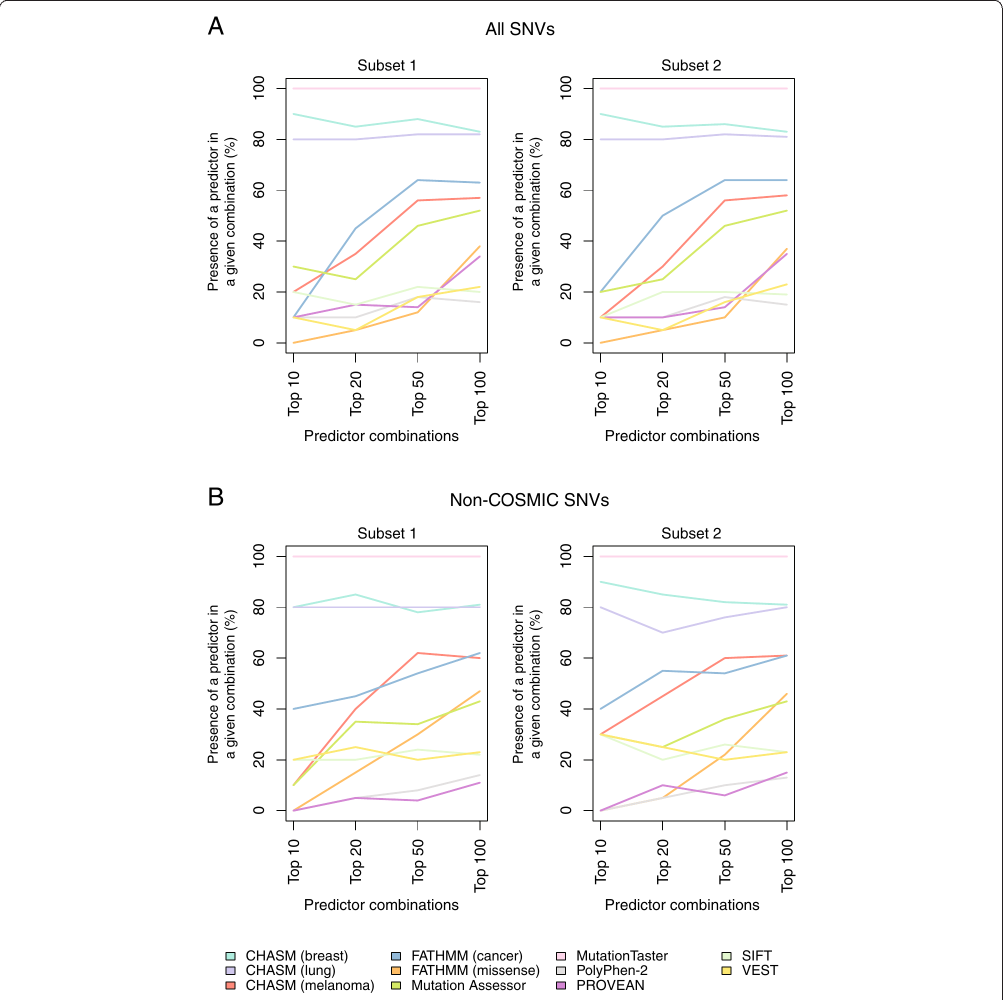

Our run

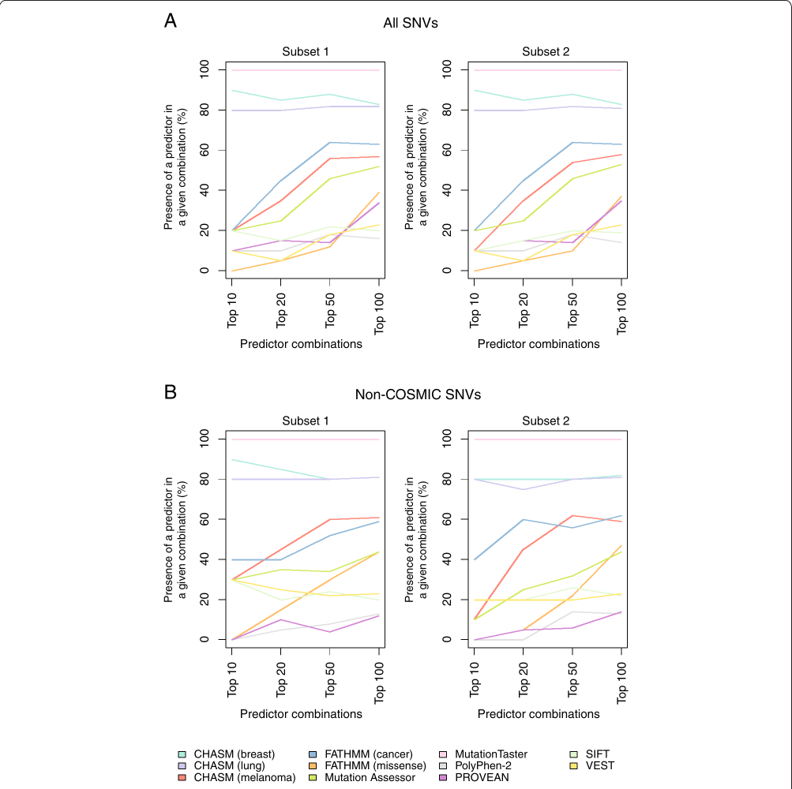

**Fig. 4A, how often each predictor is in the top 10, 20, 50 and 100 combinations, all SNVs**

74 of 88 values, Partly agrees

**Fig. 4B, the same for the non-COSMIC SNVs**

43 of 88 values, Partly agrees

Rankings and counts over 11,253 combinations depend on the random splits: neighbours in the ranking differ by less than the Monte Carlo error, so another set of splits reorders them, and combinations near a reference value move across it.

## Tables 3 and 4

Every point value came back. The intervals come from random resampling: 180 of 180 and 179 of 180 interval ends are within the spread of our own repeat runs.

## Table 3, performance on the 989 labelled SNVs

Paper above, ours below, in percent (composite 0 to 4); shaded where a value of ours is outside its tolerance. Point values 90 of 90, interval ends 180 of 180.

Agrees

| Predictor | Accuracy | Sensitivity | Specificity | PPV | NPV | Composite |
| --- | --- | --- | --- | --- | --- | --- |
| CHASM (breast) | 88.68 (86.55-90.70) 88.68 (86.55-90.50) | 89.99 (87.81-91.92) 89.99 (87.89-91.85) | 80.71 (73.33-87.12) 80.71 (73.64-87.05) | 96.59 (95.20-97.73) 96.59 (95.18-97.81) | 57.07 (50.23-64.58) 57.07 (50.00-64.17) | 3.2436 (3.1127-3.3669) 3.2436 (3.1135-3.3594) |
| CHASM (lung) | 90.09 (88.27-91.81) 90.09 (88.07-91.81) | 92.23 (90.40-94.04) 92.23 (90.30-94.04) | 77.14 (69.93-83.58) 77.14 (69.86-83.78) | 96.07 (94.74-97.31) 96.07 (94.69-97.30) | 62.07 (54.72-69.38) 62.07 (54.94-69.23) | 3.2751 (3.1418-3.3988) 3.2751 (3.1464-3.4039) |
| CHASM (melanoma) | 89.69 (87.77-91.51) 89.69 (87.77-91.51) | 93.64 (92.00-95.37) 93.64 (91.96-95.26) | 65.71 (57.35-73.51) 65.71 (57.58-73.19) | 94.31 (92.67-95.76) 94.31 (92.60-95.73) | 63.01 (55.40-70.92) 63.01 (55.07-71.24) | 3.1667 (3.0181-3.3079) 3.1667 (3.0175-3.3102) |
| FATHMM (cancer) | 91.00 (89.18-92.62) 91.00 (89.08-92.82) | 97.88 (96.87-98.82) 97.88 (96.84-98.82) | 49.29 (41.08-57.24) 49.29 (41.12-57.93) | 92.13 (90.26-93.72) 92.13 (90.16-93.95) | 79.31 (70.59-87.66) 79.31 (70.71-87.84) | 3.1860 (3.0326-3.3292) 3.1860 (3.0306-3.3310) |
| FATHMM (missense) | 82.51 (79.98-84.73) 82.51 (79.98-84.84) | 87.75 (85.46-89.94) 87.75 (85.53-89.94) | 50.71 (42.98-58.27) 50.71 (41.96-58.96) | 91.52 (89.53-93.23) 91.52 (89.60-93.44) | 40.57 (33.53-47.72) 40.57 (33.33-47.75) | 2.7056 (2.5576-2.8521) 2.7056 (2.5465-2.8524) |
| Mutation Assessor | 74.70 (71.89-77.51) 74.70 (72.17-77.53) | 76.65 (73.87-79.65) 76.65 (73.94-79.53) | 62.86 (54.61-71.21) 62.86 (54.81-70.77) | 92.59 (90.35-94.55) 92.59 (90.65-94.48) | 30.77 (25.69-36.70) 30.77 (25.99-35.95) | 2.6287 (2.4835-2.7842) 2.6287 (2.5006-2.7652) |
| MutationTaster | 88.57 (86.65-90.60) 88.57 (86.55-90.60) | 90.81 (88.94-92.84) 90.81 (88.89-92.61) | 75.00 (66.91-82.00) 75.00 (68.03-81.89) | 95.66 (94.10-97.00) 95.66 (94.20-97.03) | 57.38 (50.00-65.14) 57.38 (50.52-64.60) | 3.1885 (3.0502-3.3300) 3.1885 (3.0533-3.3138) |
| PolyPhen-2 | 79.78 (77.05-82.11) 79.78 (77.05-82.20) | 84.22 (81.83-86.61) 84.22 (81.67-86.82) | 52.86 (44.51-61.15) 52.86 (44.27-61.15) | 91.55 (89.45-93.40) 91.55 (89.33-93.46) | 35.58 (29.44-42.16) 35.58 (28.93-42.09) | 2.6420 (2.4895-2.7915) 2.6420 (2.4831-2.7932) |
| PROVEAN | 73.71 (70.88-76.64) 73.71 (71.08-76.44) | 74.44 (71.51-77.43) 74.44 (71.61-77.26) | 69.29 (61.72-76.06) 69.29 (61.38-76.81) | 93.63 (91.82-95.31) 93.63 (91.63-95.43) | 30.89 (25.93-36.56) 30.89 (26.07-35.76) | 2.6825 (2.5505-2.8088) 2.6825 (2.5477-2.8030) |
| SIFT | 80.99 (78.26-83.42) 80.99 (78.67-83.42) | 86.10 (83.89-88.45) 86.10 (83.76-88.33) | 50.00 (41.93-58.40) 50.00 (41.96-57.94) | 91.26 (89.08-93.15) 91.26 (89.28-93.10) | 37.23 (30.34-44.28) 37.23 (30.46-44.17) | 2.6460 (2.4895-2.7968) 2.6460 (2.4967-2.7917) |
| VEST | 75.03 (72.50-77.76) 75.03 (72.40-77.65) | 82.69 (80.28-85.24) 82.69 (80.29-85.17) | 28.57 (21.01-35.40) 28.57 (21.32-36.30) | 87.53 (85.12-89.75) 87.53 (85.09-89.60) | 21.39 (15.91-27.57) 21.39 (15.58-27.69) | 2.2018 (2.0568-2.3395) 2.2018 (2.0638-2.3408) |
| CanDrA (breast) | 81.81 (79.23-84.26) 81.81 (79.47-84.15) | 95.38 (93.85-96.81) 95.38 (93.97-96.71) | 0 (0-0) 0 (0-0) | 85.19 (82.83-87.30) 85.19 (82.93-87.39) | 0 (0-0) 0 (0-0) | 1.8056 (1.7765-1.8340) 1.8056 (1.7787-1.8332) |
| CanDrA (lung) | 91.28 (89.54-93.04) 91.28 (89.50-93.07) | 92.86 (91.05-94.62) 92.86 (91.08-94.50) | 80.95 (73.64-87.32) 80.95 (73.87-87.50) | 96.97 (95.75-98.03) 96.97 (95.75-98.08) | 63.35 (56.10-71.01) 63.35 (55.62-70.70) | 3.3413 (3.2103-3.4747) 3.3413 (3.1976-3.4678) |
| CanDrA (melanoma) | 88.97 (87.02-90.91) 88.97 (86.94-91.01) | 90.73 (88.69-92.81) 90.73 (88.59-92.67) | 77.60 (69.57-84.40) 77.60 (70.59-84.80) | 96.33 (94.89-97.53) 96.33 (94.89-97.59) | 56.40 (48.77-63.74) 56.40 (48.73-63.53) | 3.2105 (3.0705-3.3507) 3.2105 (3.0754-3.3365) |
| Condel | 85.84 (83.42-88.17) 85.84 (83.52-87.87) | 92.58 (90.81-94.28) 92.58 (90.78-94.19) | 45.00 (37.06-53.72) 45.00 (36.77-52.68) | 91.08 (89.16-92.94) 91.08 (89.03-92.80) | 50.00 (41.43-59.06) 50.00 (41.07-58.20) | 2.7866 (2.6222-2.9552) 2.7866 (2.6170-2.9465) |

## Table 4, performance on the 297 labelled non-COSMIC SNVs

Paper above, ours below, in percent (composite 0 to 4); shaded where a value of ours is outside its tolerance. Point values 90 of 90, interval ends 179 of 180.

Partly agrees

| Predictor | Accuracy | Sensitivity | Specificity | PPV | NPV | Composite |
| --- | --- | --- | --- | --- | --- | --- |
| CHASM (breast) | 80.13 (75.42-84.18) 80.13 (75.42-84.51) | 72.34 (65.70-78.34) 72.34 (65.66-78.62) | 93.58 (88.89-97.96) 93.58 (88.57-97.96) | 95.10 (91.27-98.47) 95.10 (91.15-98.46) | 66.23 (58.62-73.42) 66.23 (59.21-73.61) | 3.2726 (3.1090-3.4151) 3.2726 (3.1062-3.4212) |
| CHASM (lung) | 82.49 (78.11-86.53) 82.49 (77.78-86.54) | 79.26 (73.26-84.95) 79.26 (73.06-84.77) | 88.07 (81.98-94.18) 88.07 (81.31-93.46) | 91.98 (87.58-96.20) 91.98 (87.64-95.73) | 71.11 (63.57-78.74) 71.11 (62.79-78.91) | 3.3042 (3.1370-3.4665) 3.3041 (3.1150-3.4641) |
| CHASM (melanoma) | 81.82 (77.44-86.20) 81.82 (77.44-86.20) | 86.17 (80.93-90.96) 86.17 (81.35-91.15) | 74.31 (65.71-82.46) 74.31 (65.95-82.17) | 85.26 (80.21-90.00) 85.26 (80.10-90.12) | 75.70 (67.29-83.91) 75.70 (67.29-83.81) | 3.2145 (3.0259-3.3971) 3.2145 (3.0130-3.3996) |
| FATHMM (cancer) | 80.13 (75.42-84.51) 80.13 (75.42-84.51) | 92.02 (87.98-95.83) 92.02 (87.96-95.56) | 59.63 (50.43-69.00) 59.63 (50.00-68.37) | 79.72 (74.21-84.82) 79.72 (73.93-84.69) | 81.25 (72.06-89.22) 81.25 (72.15-89.16) | 3.1263 (2.9242-3.3078) 3.1263 (2.9143-3.3074) |
| FATHMM (missense) | 75.42 (70.71-79.80) 75.42 (70.37-79.81) | 86.70 (81.82-91.37) 86.70 (81.82-91.30) | 55.96 (46.29-64.82) 55.96 (46.02-64.41) | 77.25 (71.67-82.33) 77.25 (71.56-82.65) | 70.93 (60.92-80.23) 70.93 (60.91-79.52) | 2.9085 (2.7014-3.1033) 2.9085 (2.6882-3.0923) |
| Mutation Assessor | 68.69 (63.64-73.40) 68.69 (63.30-74.07) | 71.28 (64.77-77.25) 71.28 (64.77-77.96) | 64.22 (54.46-72.81) 64.22 (54.63-72.90) | 77.46 (71.26-82.93) 77.46 (71.26-82.93) | 56.45 (47.82-64.87) 56.45 (47.65-65.26) | 2.6941 (2.4757-2.8892) 2.6940 (2.4674-2.9146) |
| MutationTaster | 84.51 (80.13-88.55) 84.51 (80.13-88.55) | 84.04 (78.53-89.25) 84.04 (78.53-89.08) | 85.32 (78.18-91.75) 85.32 (78.43-91.59) | 90.80 (86.05-95.00) 90.80 (86.19-94.71) | 75.61 (67.42-82.88) 75.61 (67.85-82.91) | 3.3578 (3.1879-3.5244) 3.3578 (3.1837-3.5186) |
| PolyPhen-2 | 69.36 (64.31-74.41) 69.36 (63.64-74.41) | 78.72 (73.16-84.53) 78.72 (72.45-84.70) | 53.21 (43.59-62.50) 53.21 (44.21-61.61) | 74.37 (68.08-80.21) 74.37 (67.66-80.30) | 59.18 (49.47-69.01) 59.18 (50.00-69.47) | 2.6549 (2.4296-2.8672) 2.6549 (2.4283-2.8761) |
| PROVEAN | 58.59 (52.86-63.64) 58.59 (53.20-64.31) | 51.06 (43.78-57.73) 51.06 (44.33-57.61) | 71.56 (62.83-80.00) 71.56 (62.74-80.00) | 75.59 (68.61-82.81) 75.59 (68.61-83.20) | 45.88 (38.61-53.76) 45.88 (38.27-53.46) | 2.4410 (2.2263-2.6521) 2.4410 (2.2361-2.6680) |
| SIFT | 69.70 (64.65-74.75) 69.70 (64.31-74.41) | 81.91 (76.09-87.57) 81.91 (75.95-87.50) | 48.62 (38.89-58.62) 48.62 (39.64-57.55) | 73.33 (67.31-78.92) 73.33 (66.83-78.97) | 60.92 (51.14-71.64) 60.92 (50.00-71.27) | 2.6479 (2.4175-2.8681) 2.6479 (2.4127-2.8534) |
| VEST | 54.88 (49.49-60.27) 54.88 (49.15-60.61) | 71.81 (65.80-77.89) 71.81 (64.83-78.11) | 25.69 (18.01-34.19) 25.69 (17.82-34.05) | 62.50 (56.34-68.78) 62.50 (56.42-68.94) | 34.57 (24.99-45.21) 34.57 (24.69-45.68) | 1.9456 (1.7302-2.1701) 1.9456 (1.7073-2.1729) |
| CanDrA (breast) | 61.69 (55.89-66.78) 61.69 (56.27-67.47) | 97.85 (95.50-99.48) 97.85 (95.63-99.48) | 0 (0-0) 0 (0-0) | 62.54 (57.04-67.82) 62.54 (57.04-68.26) | 0 (0-0) 0 (0-0) | 1.6039 (1.5437-1.6593) 1.6039 (1.5436-1.6652) |
| CanDrA (lung) | 84.70 (80.50-88.65) 84.70 (80.43-88.97) | 79.12 (73.21-84.57) 79.12 (73.03-84.83) | 94.95 (89.81-98.94) 94.95 (90.24-98.95) | 96.64 (93.29-99.31) 96.64 (93.71-99.32) | 71.21 (63.41-78.30) 71.21 (63.04-79.17) | 3.4193 (3.2675-3.5628) 3.4193 (3.2720-3.5717) |
| CanDrA (melanoma) | 82.61 (77.94-86.64) 82.61 (77.89-86.96) | 78.09 (71.43-83.82) 78.09 (72.16-84.00) | 90.82 (85.06-96.00) 90.82 (84.69-96.15) | 93.92 (89.86-97.33) 93.92 (89.65-97.42) | 69.53 (61.10-77.05) 69.53 (61.42-77.20) | 3.3236 (3.1491-3.4780) 3.3236 (3.1394-3.4824) |
| Condel | 76.77 (72.05-81.48) 76.77 (71.72-81.83) | 93.09 (89.36-96.32) 93.09 (89.36-96.77) | 48.62 (39.62-58.33) 48.62 (38.84-58.72) | 75.76 (70.38-81.03) 75.76 (70.00-81.30) | 80.30 (70.58-89.55) 80.30 (70.49-89.66) | 2.9777 (2.7814-3.1877) 2.9777 (2.7550-3.1911) |

The intervals come from unseeded resampling. The fields outside three standard deviations are the tail one expects among hundreds of interval ends, or intervals of tiny groups (7 neutral SNVs among the oncogenes) whose ends jump between few possible values.

## Every result

75 results: 9 exact, 40 agree, 23 partly agree, 1 differ, 2 not attempted. Each verdict is computed from the numbers by check_results.py.

Result

Verdict

Measure

Why

Table 1, SNVs by gene and functional category

Exact

64 of 64 values

Table 2, calls of the 15 predictors by functional category

Exact

160 of 160 values

Table 3, performance on the 989 labelled SNVs (point values)

Agrees

90 of 90 values

Table 3, bootstrap 95% intervals

Agrees

180 of 180 values

Table 4, performance on the 297 labelled non-COSMIC SNVs (point values)

Agrees

90 of 90 values

Table 4, bootstrap 95% intervals

Partly agrees

179 of 180 values

The intervals come from unseeded resampling. The fields outside three standard deviations are the tail one expects among hundreds of interval ends, or intervals of tiny groups (7 neutral SNVs among the oncogenes) whose ends jump between few possible values.

Fig. 1A, clustering of the calls of all 3,591 SNVs (clades, join heights, row shares)

Agrees

71 of 71 values

Fig. 1B, kappa of each pair of predictors, all SNVs (cell colours)

Agrees

225 of 225 values

Fig. 1C, clustering of the calls of the 1,699 non-COSMIC SNVs

Agrees

71 of 71 values

Fig. 1D, kappa of each pair of predictors, non-COSMIC SNVs (cell colours)

Agrees

225 of 225 values

Fig. 2A, performance on the 989 labelled SNVs (bars)

Agrees

90 of 90 values

Fig. 2A, error bars

Agrees

176 of 176 values

Fig. 2B, performance on the 297 non-COSMIC SNVs (bars)

Agrees

90 of 90 values

Fig. 2B, error bars

Agrees

176 of 176 values

Fig. 3A, top five combinations by composite score, all SNVs, subset 1 (names, bars, error bars, significance marks)

Agrees

151 of 151 values

Fig. 3B, top five combinations by composite score, all SNVs, subset 2 (names, bars, error bars, significance marks)

Partly agrees

147 of 151 values

Rankings and counts over 11,253 combinations depend on the random splits: neighbours in the ranking differ by less than the Monte Carlo error, so another set of splits reorders them, and combinations near a reference value move across it.

Fig. 3C, top five combinations by composite score, non-COSMIC SNVs, subset 1 (names, bars, error bars, significance marks)

Partly agrees

144 of 151 values

Rankings and counts over 11,253 combinations depend on the random splits: neighbours in the ranking differ by less than the Monte Carlo error, so another set of splits reorders them, and combinations near a reference value move across it.

Fig. 3D, top five combinations by composite score, non-COSMIC SNVs, subset 2 (names, bars, error bars, significance marks)

Partly agrees

144 of 151 values

Rankings and counts over 11,253 combinations depend on the random splits: neighbours in the ranking differ by less than the Monte Carlo error, so another set of splits reorders them, and combinations near a reference value move across it.

Fig. 4A, how often each predictor is in the top 10, 20, 50 and 100 combinations, all SNVs

Partly agrees

74 of 88 values

Rankings and counts over 11,253 combinations depend on the random splits: neighbours in the ranking differ by less than the Monte Carlo error, so another set of splits reorders them, and combinations near a reference value move across it.

Fig. 4B, the same for the non-COSMIC SNVs

Partly agrees

43 of 88 values

Rankings and counts over 11,253 combinations depend on the random splits: neighbours in the ranking differ by less than the Monte Carlo error, so another set of splits reorders them, and combinations near a reference value move across it.

Additional file 3, kappa and its interval for every pair of predictors (all and non-COSMIC SNVs)

Agrees

720 of 720 values

Additional file 5, kappa for the 989 labelled and the 297 labelled non-COSMIC SNVs

Agrees

720 of 720 values

Additional file 8, three-category calls (with low confidence) by functional category

Agrees

379 of 379 values (5 paper slips left out)

Additional file 8's Mutation Assessor rows sum to 3,584 of the 3,591 SNVs (1,697 of the 1,699 without COSMIC): the SNVs with N/A (7, and 2 without COSMIC) are left out, while Additional file 9's counts need them as low-confidence calls. Our row holds them: 1,106 = 1,099 + 7, and 608 = 606 + 2.; Additional file 8's Mutation Assessor rows sum to 3,584 of the 3,591 SNVs (1,697 of the 1,699 without COSMIC): the SNVs with N/A (7, and 2 without COSMIC) are left out, while Additional file 9's counts need them as low-confidence calls. Our row holds them: 1,106 = 1,099 + 7, and 608 = 606 + 2.; Additional file 8's Mutation Assessor rows sum to 3,584 of the 3,591 SNVs (1,697 of the 1,699 without COSMIC): the SNVs with N/A (7, and 2 without COSMIC) are left out, while Additional file 9's counts need them as low-confidence calls. Our row holds them: 1,106 = 1,099 + 7, and 608 = 606 + 2.; Additional file 8's Mutation Assessor rows sum to 3,584 of the 3,591 SNVs (1,697 of the 1,699 without COSMIC): the SNVs with N/A (7, and 2 without COSMIC) are left out, while Additional file 9's counts need them as low-confidence calls. Our row holds them: 1,106 = 1,099 + 7, and 608 = 606 + 2.; Additional file 8's Mutation Assessor rows sum to 3,584 of the 3,591 SNVs (1,697 of the 1,699 without COSMIC): the SNVs with N/A (7, and 2 without COSMIC) are left out, while Additional file 9's counts need them as low-confidence calls. Our row holds them: 1,106 = 1,099 + 7, and 608 = 606 + 2.

Additional file 9, SNVs by number of low-confidence calls, and those with eight or more

Agrees

67 of 67 values (1 paper slip left out)

The list for all SNVs puts G451V under ERBB2; in Additional file 2 G451V is a PIK3CA mutation and ERBB2 has no G451V. Everything else in the list is ours.

Additional file 11, kappa with the low-confidence category (all and non-COSMIC SNVs)

Agrees

720 of 720 values

Additional file 13, kappa with the low-confidence category (989 and 297 labelled SNVs)

Agrees

720 of 720 values

Additional file 16, performance in oncogenes (176 SNVs) and tumour suppressor genes (783)

Agrees

180 of 180 values

Additional file 16, bootstrap 95% intervals

Partly agrees

352 of 360 values

Most of the interval ends outside the tolerance belong to the oncogenes, which have 7 neutral SNVs, so the ends of specificity, NPV and composite jump between a few possible values. Three of them do not move at all across our 20 repeat bootstraps and still miss: CanDrA (melanoma) specificity low end (printed 14.29%, ours 0% in every repeat), CanDrA (lung) NPV low end (11.11%, ours 0% or near it) and CanDrA (lung) accuracy high end (98.15%, ours 98.12%). Tables 3 and 4 do not show this, so the paper's resampling of the oncogene set differed in a way we have not found.

Additional file 17, all 11,253 combinations on the 989 labelled SNVs (means and intervals in both subsets)

Agrees

135,036 of 135,036 means (11,253 combinations x 6 statistics x 2 subsets) within the printed precision plus three Monte Carlo standard deviations; 268,491 of 270,072 interval ends within three times the run-to-run spread. Control: our run on the other data set puts 10,831 of 135,036 means within.

Additional file 18, all 11,253 combinations on the 297 labelled non-COSMIC SNVs

Agrees

135,036 of 135,036 means (11,253 combinations x 6 statistics x 2 subsets) within the printed precision plus three Monte Carlo standard deviations; 268,138 of 270,072 interval ends within three times the run-to-run spread. Control: our run on the other data set puts 10,530 of 135,036 means within.

Additional file 19, combinations that beat the best single and meta-predictor

Partly agrees

52 of 144 values

Counts of combinations above a reference move with the random splits: our two runs differ from each other by a median of 3 combinations (at most 252) and from the paper by a median of 2 (at most 252); the first run matches 52 of 144 printed counts, the second 48. The counts recomputed from the paper's own Additional files 17 and 18 also come back only to within a few combinations, because the printed means are rounded at the reference values.

Additional file 21, top five combinations by accuracy and by composite score, 989 SNVs

Partly agrees

385 of 388 values

Rankings and counts over 11,253 combinations depend on the random splits: neighbours in the ranking differ by less than the Monte Carlo error, so another set of splits reorders them, and combinations near a reference value move across it.

Additional file 22, top five combinations, 297 non-COSMIC SNVs

Partly agrees

370 of 388 values

Rankings and counts over 11,253 combinations depend on the random splits: neighbours in the ranking differ by less than the Monte Carlo error, so another set of splits reorders them, and combinations near a reference value move across it.

Additional file 25, optimal p for each n and n for each p, 989 SNVs

Partly agrees

41 of 42 values

Rankings and counts over 11,253 combinations depend on the random splits: neighbours in the ranking differ by less than the Monte Carlo error, so another set of splits reorders them, and combinations near a reference value move across it.

Additional file 27, optimal p and n, 297 non-COSMIC SNVs

Partly agrees

37 of 42 values

Rankings and counts over 11,253 combinations depend on the random splits: neighbours in the ranking differ by less than the Monte Carlo error, so another set of splits reorders them, and combinations near a reference value move across it.

Additional file 28, training-set SNVs left among the labelled SNVs

Exact

12 of 12 values

- CHASM (breast) 989: paper 570, ours **570**
- CHASM (breast) 297: paper 51, ours **51**
- CHASM (lung) 989: paper 570, ours **570**
- CHASM (lung) 297: paper 51, ours **51**
- CHASM (melanoma) 989: paper 570, ours **570**
- CHASM (melanoma) 297: paper 51, ours **51**
- FATHMM (cancer) 989: paper 682, ours **682**
- FATHMM (cancer) 297: paper 68, ours **68**
- FATHMM (missense) 989: paper 158, ours **158**
- FATHMM (missense) 297: paper 48, ours **48**
- PolyPhen-2 989: paper 14, ours **14**
- PolyPhen-2 297: paper 4, ours **4**

Additional file 4, kappa heat maps for the 989 and the 297 labelled SNVs (cell colours; the call heat maps and dendrograms are not compared)

Agrees

450 of 450 values

Additional file 6, the 1,699 non-COSMIC SNVs by gene and functional category

Exact

64 of 64 values

Additional file 7, calls of the 15 predictors on the 1,699 non-COSMIC SNVs

Exact

158 of 158 values (2 paper slips left out)

Additional file 7's PolyPhen-2 rows sum to 1,698 of the 1,699 non-COSMIC SNVs and to 187 of the 188 non-neutral ones; Additional file 8 prints 118 and 553 for the same row (probably damaging), as we count.; Additional file 7's PolyPhen-2 rows sum to 1,698 of the 1,699 non-COSMIC SNVs and to 187 of the 188 non-neutral ones; Additional file 8 prints 118 and 553 for the same row (probably damaging), as we count.

Additional file 10, kappa heat maps with the low-confidence category, all and non-COSMIC SNVs (cell colours)

Agrees

450 of 450 values

Additional file 12, kappa heat maps with the low-confidence category, 989 and 297 labelled SNVs (cell colours)

Agrees

450 of 450 values

Additional file 14, calls on the 989 labelled SNVs by gene class

Exact

240 of 240 values

Additional file 15A, performance in oncogenes (bars)

Agrees

90 of 90 values

Additional file 15A, error bars

Partly agrees

167 of 172 values

Most of the interval ends outside the tolerance belong to the oncogenes, which have 7 neutral SNVs, so the ends of specificity, NPV and composite jump between a few possible values. Three of them do not move at all across our 20 repeat bootstraps and still miss: CanDrA (melanoma) specificity low end (printed 14.29%, ours 0% in every repeat), CanDrA (lung) NPV low end (11.11%, ours 0% or near it) and CanDrA (lung) accuracy high end (98.15%, ours 98.12%). Tables 3 and 4 do not show this, so the paper's resampling of the oncogene set differed in a way we have not found.

Additional file 15B, performance in tumour suppressor genes (bars)

Agrees

90 of 90 values

Additional file 15B, error bars

Agrees

174 of 174 values

Additional file 20A, top five combinations by accuracy, all SNVs, subset 1

Partly agrees

150 of 151 values

Rankings and counts over 11,253 combinations depend on the random splits: neighbours in the ranking differ by less than the Monte Carlo error, so another set of splits reorders them, and combinations near a reference value move across it.

Additional file 20B, top five combinations by accuracy, all SNVs, subset 2

Partly agrees

150 of 151 values

Rankings and counts over 11,253 combinations depend on the random splits: neighbours in the ranking differ by less than the Monte Carlo error, so another set of splits reorders them, and combinations near a reference value move across it.

Additional file 20C, top five combinations by accuracy, non-COSMIC SNVs, subset 1

Partly agrees

149 of 151 values

Rankings and counts over 11,253 combinations depend on the random splits: neighbours in the ranking differ by less than the Monte Carlo error, so another set of splits reorders them, and combinations near a reference value move across it.

Additional file 20D, top five combinations by accuracy, non-COSMIC SNVs, subset 2

Partly agrees

143 of 151 values

Rankings and counts over 11,253 combinations depend on the random splits: neighbours in the ranking differ by less than the Monte Carlo error, so another set of splits reorders them, and combinations near a reference value move across it.

Additional file 23A, how often each predictor is in the top combinations by accuracy, all SNVs

Partly agrees

63 of 88 values

Rankings by mean accuracy have many near ties (combinations whose accuracies differ by less than the Monte Carlo error), so the top 10 to 100 change with the random splits. Even recomputed from the accuracies printed in Additional file 17 and 18 (rounded to two decimals, so more ties), Additional file 23 comes back for 143 of 176 points.

Additional file 23B, the same for the non-COSMIC SNVs

Partly agrees

45 of 88 values

Rankings by mean accuracy have many near ties (combinations whose accuracies differ by less than the Monte Carlo error), so the top 10 to 100 change with the random splits. Even recomputed from the accuracies printed in Additional file 17 and 18 (rounded to two decimals, so more ties), Additional file 23 comes back for 143 of 176 points.

Additional file 24, box plots of the combinations' accuracy by n and p, 989 SNVs (hinges and medians)

Partly agrees

382 of 390 values

The 8 hinges and medians outside the tolerance are those of the combinations of 10 and 11 predictors that need 10 or 11 non-neutral calls; they miss by 0.1 point at most. The tolerance uses the average run-to-run spread of a combination's mean accuracy (0.025 point RMS); these combinations spread more (the one of all 11 has a standard error of 0.036 point, so 3 x sqrt(2) of it is 0.15 point, which holds the 0.097 gap). Our second run moves its mean by 0.028 point.

Additional file 26, the same box plots for the 297 non-COSMIC SNVs

Agrees

390 of 390 values

Additional file 29, performance of six predictors on all, non-COSMIC and non-training-set SNVs (bars)

Agrees

108 of 108 values

Additional file 29, error bars

Agrees

216 of 216 values

Dataset sizes and SNVs per gene class (Results)

Exact

14 of 14 values

- mutations: paper 3706, ours **3706**
- SNVs: paper 3591, ours **3591**
- non-neutral: paper 849, ours **849**
- neutral: paper 140, ours **140**
- uncertain: paper 2602, ours **2602**
- oncogenes, median labelled SNVs: paper 28.5, ours **28.5**
- oncogenes, fewest: paper 23, ours **23**
- oncogenes, most: paper 38, ours **38**
- new cancer genes, median: paper 5, ours **5**
- new cancer genes, fewest: paper 1, ours **1**
- new cancer genes, most: paper 11, ours **11**
- TSGs, median: paper 81, ours **81**
- TSGs, fewest: paper 62, ours **62**
- TSGs, most: paper 640, ours **640**

Calls of VEST and PROVEAN (Results)

Exact

4 of 4 values

- VEST functional: paper 2465, ours **2465**
- VEST neutral: paper 1126, ours **1126**
- PROVEAN deleterious: paper 1630, ours **1630**
- PROVEAN neutral: paper 1961, ours **1961**

Kappa within and between the two clusters, all SNVs (Results)

Agrees

10 of 10 values

- Cluster 1 median kappa: paper 0.5679, ours **0.5679**
- Cluster 1 lowest: paper 0.3861, ours **0.3861**
- Cluster 1 highest: paper 0.9004, ours **0.9004**
- CHASM (breast) / CHASM (lung): paper 0.9004, ours **0.9004**
- Cluster 2 median: paper 0.4347, ours **0.4347**
- Cluster 2 lowest: paper 0.3355, ours **0.3355**
- Cluster 2 highest: paper 0.5662, ours **0.5662**
- between clusters, median: paper 0.2062, ours **0.2062**
- between clusters, lowest: paper -0.0520, ours **-0.0520**
- between clusters, highest: paper 0.4216, ours **0.4216**

Cluster 1 median kappa without COSMIC SNVs (Results)

Agrees

1 of 1 values

- Cluster 1 median kappa: paper 0.4558, ours **0.4558**

SNVs not in COSMIC v68 (Results)

Exact

5 of 5 values

- SNVs not in COSMIC: paper 1699, ours **1699**
- share not in COSMIC (%): paper 47.3, ours **47.3**
- labelled SNVs not in COSMIC: paper 297, ours **297**
- non-neutral not in COSMIC: paper 188, ours **188**
- neutral not in COSMIC: paper 109, ours **109**

Cluster structure of Fig. 1A, 1C and Additional file 4 (Results)

Agrees

5 of 5 values

- all SNVs: Cluster 1 is a clade: paper yes, ours **yes**
- all SNVs: Cluster 2 is a clade: paper yes, ours **yes**
- all SNVs: CanDrA (breast) joins Cluster 1 only after its members: paper yes, ours **yes**
- non-COSMIC: VEST and CanDrA (breast) apart from both clusters: paper yes, ours **yes**
- 989 SNVs: CanDrA (breast) in Cluster 1: paper yes, ours **yes**

Low-confidence calls (Results)

Agrees

6 of 6 values (1 paper slip left out)

- median low-confidence SNVs per predictor: paper 437, ours **437**
- fewest (CanDrA (breast)): paper 44, ours **44**
- most (PROVEAN): paper 1298, ours **1298**
- most among predictors with a built-in category (Mutation Assessor): paper 1099, ours **1106**
- SNVs with 8 or more low-confidence calls: paper 27, ours **27**
- labelled SNVs of low confidence by PROVEAN only: paper 132, ours **132**
- as a share of 989 (%): paper 13.3, ours **13.3**

The 1,099 is Additional file 8's Mutation Assessor row, which leaves out its 7 N/A calls; Additional file 9's counts (and the 27 SNVs with eight or more low-confidence calls) need them as low-confidence calls, which gives 1,106.

Medians, ranges and significance calls of Table 3 (Results)

Partly agrees

26 of 27 values

A significance call near the edge: whether FATHMM (cancer)'s NPV interval reaches CanDrA (lung)'s depends on the resamples. The published call comes back in 13 of 20 of our 20 repeat bootstraps; from the paper's own Table 3 it comes back.

Table 4 and the loss of accuracy without COSMIC SNVs (Results)

Partly agrees

10 of 12 values

- accuracy median: paper 76.77, ours **76.77**
- accuracy lowest: paper 54.88, ours **54.88**
- accuracy highest: paper 84.70, ours **84.70**
- sensitivity median: paper 79.26, ours **79.26**
- sensitivity lowest: paper 51.06, ours **51.06**
- sensitivity highest: paper 97.85, ours **97.85**
- most accurate single predictor (MutationTaster): paper MutationTaster, ours **MutationTaster**
- most accurate meta-predictor (CanDrA (lung)): paper CanDrA (lung), ours **CanDrA (lung)**
- predictors whose accuracy is significantly lower without COSMIC: paper 13, ours **12**
- the two whose accuracy is not: paper Mutation Assessor, MutationTaster, ours **Mutation Assessor, MutationTaster, CanDrA (melanoma)**
- significantly lower sensitivity: paper 8, ours **8**
- significantly lower PPV: paper 10, ours **10**

CanDrA (melanoma)'s accuracy without COSMIC (Table 4 high end 86.64%) and with it (Table 3 low end 87.02%) almost touch, so whether the drop is significant depends on the resamples: 13 predictors in the paper, 12 in our run. From the paper's own intervals the call comes back, but only 2 of 20 of our 20 repeat bootstraps give it, so a different seed alone is an unlikely cause; the paper's interval method may differ in a way the other intervals do not show.

Oncogenes against tumour suppressor genes (Results)

Agrees

14 of 14 values

- SNVs in oncogenes: paper 176, ours **176**
- SNVs in TSGs: paper 783, ours **783**
- SNVs in new cancer genes: paper 30, ours **30**
- oncogenes: most accurate single predictor: paper FATHMM (cancer), ours **FATHMM (cancer)**
- oncogenes: its accuracy: paper 96.59, ours **96.59**
- oncogenes: most accurate meta-predictor: paper CanDrA (lung), ours **CanDrA (lung)**
- oncogenes: its accuracy: paper 95.00, ours **95.00**
- TSGs: most accurate single predictor: paper CHASM (lung), ours **CHASM (lung)**
- TSGs: its accuracy: paper 92.98, ours **92.98**
- TSGs: most accurate meta-predictor: paper CanDrA (melanoma), ours **CanDrA (melanoma)**
- TSGs: its accuracy: paper 93.46, ours **93.46**
- significantly more accurate in TSGs: paper CHASM (breast), CHASM (melanoma), CanDrA (melanoma), Condel, FATHMM (missense), Mutation Assessor, ours **CHASM (breast), CHASM (melanoma), CanDrA (melanoma), Condel, FATHMM (missense), Mutation Assessor**
- significantly more accurate in oncogenes: paper FATHMM (cancer), MutationTaster, PROVEAN, PolyPhen-2, VEST, ours **FATHMM (cancer), MutationTaster, PROVEAN, PolyPhen-2, VEST**
- Fisher's exact test of the neutral share below 0.0001: paper yes, ours **yes**

The combinations against FATHMM (cancer) and CHASM (lung), and the best combination (Results)

Partly agrees

16 of 19 values

- combinations: paper 11253, ours **11253**
- higher mean accuracy than FATHMM (cancer) in both subsets: paper 1854, ours **1854**
- of these, significantly higher in both: paper 6, ours **5**
- higher mean composite than CHASM (lung) in both subsets: paper 1483, ours **1497**
- of these, significantly higher in both: paper 5, ours **4**
- first by accuracy and composite in both subsets: paper At least 1 of CHASM (breast), MutationTaster, ours **At least 1 of CHASM (breast), MutationTaster**
- At least 1 of CHASM (breast), MutationTaster, subset1, accuracy mean: paper 95.46, ours **95.46**
- At least 1 of CHASM (breast), MutationTaster, subset1, accuracy low: paper 94.54, ours **94.54**
- At least 1 of CHASM (breast), MutationTaster, subset1, accuracy high: paper 96.51, ours **96.36**
- At least 1 of CHASM (breast), MutationTaster, subset1, composite mean: paper 3.6255, ours **3.6258**
- At least 1 of CHASM (breast), MutationTaster, subset1, composite low: paper 3.5584, ours **3.5594**
- At least 1 of CHASM (breast), MutationTaster, subset1, composite high: paper 3.6982, ours **3.6978**
- At least 1 of CHASM (breast), MutationTaster, subset2, accuracy mean: paper 95.43, ours **95.43**
- At least 1 of CHASM (breast), MutationTaster, subset2, accuracy low: paper 93.33, ours **93.63**
- At least 1 of CHASM (breast), MutationTaster, subset2, accuracy high: paper 97.27, ours **97.27**
- At least 1 of CHASM (breast), MutationTaster, subset2, composite mean: paper 3.6236, ours **3.6232**
- At least 1 of CHASM (breast), MutationTaster, subset2, composite low: paper 3.4841, ours **3.4802**
- At least 1 of CHASM (breast), MutationTaster, subset2, composite high: paper 3.7573, ours **3.7531**
- non-COSMIC: combinations significantly more accurate than MutationTaster in both subsets: paper 1, ours **1**

The counts and the best combination's means and intervals come from random splits. Our second run gives 1854 combinations above FATHMM (cancer)'s accuracy in both subsets (5 significantly) and 1491 above CHASM (lung)'s composite (4 significantly), against the paper's 1,854 (6) and 1,483 (5). Recomputed from the means and intervals the paper prints in Additional file 17 (arithmetic column), the counts are 1,853 (6) and 1,482 (5): the printed means are rounded, so combinations right at FATHMM (cancer)'s or CHASM (lung)'s value can fall either way. The best combination's values come back from Additional file 21.

The best combination's NPV gain in every subset (Results, Discussion)

Agrees

4 of 4 values

- all, subset1: NPV significantly above the best single and meta-predictor: paper yes, ours **yes**
- all, subset2: NPV significantly above the best single and meta-predictor: paper yes, ours **yes**
- non_cosmic, subset1: NPV significantly above the best single and meta-predictor: paper yes, ours **yes**
- non_cosmic, subset2: NPV significantly above the best single and meta-predictor: paper yes, ours **yes**

MutationTaster and CHASM (breast, lung) lead the top combinations (Results, Fig. 4)

Agrees

16 of 16 values

- all, subset1, top 10: MutationTaster, CHASM (breast) and CHASM (lung) at least as frequent as any other: paper yes, ours **yes**
- all, subset1, top 20: MutationTaster, CHASM (breast) and CHASM (lung) at least as frequent as any other: paper yes, ours **yes**
- all, subset1, top 50: MutationTaster, CHASM (breast) and CHASM (lung) at least as frequent as any other: paper yes, ours **yes**
- all, subset1, top 100: MutationTaster, CHASM (breast) and CHASM (lung) at least as frequent as any other: paper yes, ours **yes**
- all, subset2, top 10: MutationTaster, CHASM (breast) and CHASM (lung) at least as frequent as any other: paper yes, ours **yes**
- all, subset2, top 20: MutationTaster, CHASM (breast) and CHASM (lung) at least as frequent as any other: paper yes, ours **yes**
- all, subset2, top 50: MutationTaster, CHASM (breast) and CHASM (lung) at least as frequent as any other: paper yes, ours **yes**
- all, subset2, top 100: MutationTaster, CHASM (breast) and CHASM (lung) at least as frequent as any other: paper yes, ours **yes**
- non_cosmic, subset1, top 10: MutationTaster, CHASM (breast) and CHASM (lung) at least as frequent as any other: paper yes, ours **yes**
- non_cosmic, subset1, top 20: MutationTaster, CHASM (breast) and CHASM (lung) at least as frequent as any other: paper yes, ours **yes**
- non_cosmic, subset1, top 50: MutationTaster, CHASM (breast) and CHASM (lung) at least as frequent as any other: paper yes, ours **yes**
- non_cosmic, subset1, top 100: MutationTaster, CHASM (breast) and CHASM (lung) at least as frequent as any other: paper yes, ours **yes**
- non_cosmic, subset2, top 10: MutationTaster, CHASM (breast) and CHASM (lung) at least as frequent as any other: paper yes, ours **yes**
- non_cosmic, subset2, top 20: MutationTaster, CHASM (breast) and CHASM (lung) at least as frequent as any other: paper yes, ours **yes**
- non_cosmic, subset2, top 50: MutationTaster, CHASM (breast) and CHASM (lung) at least as frequent as any other: paper yes, ours **yes**
- non_cosmic, subset2, top 100: MutationTaster, CHASM (breast) and CHASM (lung) at least as frequent as any other: paper yes, ours **yes**

Removing COSMIC or training-set SNVs never raises accuracy significantly (Discussion)

Agrees

12 of 12 values

- CHASM (breast), non-COSMIC: accuracy not significantly above all SNVs: paper yes, ours **yes**
- CHASM (breast), without the training set: accuracy not significantly above all SNVs: paper yes, ours **yes**
- CHASM (lung), non-COSMIC: accuracy not significantly above all SNVs: paper yes, ours **yes**
- CHASM (lung), without the training set: accuracy not significantly above all SNVs: paper yes, ours **yes**
- CHASM (melanoma), non-COSMIC: accuracy not significantly above all SNVs: paper yes, ours **yes**
- CHASM (melanoma), without the training set: accuracy not significantly above all SNVs: paper yes, ours **yes**
- FATHMM (cancer), non-COSMIC: accuracy not significantly above all SNVs: paper yes, ours **yes**
- FATHMM (cancer), without the training set: accuracy not significantly above all SNVs: paper yes, ours **yes**
- FATHMM (missense), non-COSMIC: accuracy not significantly above all SNVs: paper yes, ours **yes**
- FATHMM (missense), without the training set: accuracy not significantly above all SNVs: paper yes, ours **yes**
- PolyPhen-2, non-COSMIC: accuracy not significantly above all SNVs: paper yes, ours **yes**
- PolyPhen-2, without the training set: accuracy not significantly above all SNVs: paper yes, ours **yes**

Optimal n and p (Results)

Differs

0 of 0 values (2 paper slips left out)

- for n = 1 to 4, the best p is about 2n: paper yes, ours **no**
- for p = 3 to 11, the best n is about p/2: paper yes, ours **no**

Both sentences have n and p swapped: the paper's own Additional file 25, and our run, give a best n of about 2p (p about n/2), capped at all 11 predictors. Our run gives the same optimal p or n as Additional file 25 in all 21 rows; in one row (n = 8) the best combination has SIFT where the file has VEST (af25). Additional file 25 (B) gives p = 1, 1, 2 for n = 2, 3, 4: the best p is about n/2 (n about 2p), as the next sentence's 'n approximately p/2' would say were it also reversed. p <= n everywhere, so p about 2n cannot hold.; Additional file 25 (A) gives n = 6, 7, 9, 10 for p = 3 to 6 and n = 11 (all predictors) for p = 7 to 11: the best n is about 2p, capped at 11. n >= p everywhere, so n about p/2 cannot hold.

The text's statements recomputed from the paper's own tables (arithmetic check)

Agrees

133 of 135 statements recomputed from the paper's own tables come back. Not: text_optimal: for n = 1 to 4, the best p is about 2n (printed yes, from the tables no); text_optimal: for p = 3 to 11, the best n is about p/2 (printed yes, from the tables no). Fig. 4 recomputed from the means printed in Additional files 17 and 18: 173 of 176 points.

Additional file 1, overview of the predictors

Not attempted

A diagram of the 15 predictors and their features; nothing to recompute.

The authors' statistical code

Not attempted

Never released: the paper has no code or availability statement, and no copy was found (fossil issue #97 lists the searches). The method is rebuilt from the text as the package mutbench.

Python package mutbench and its tutorial

Agrees

mutbench 0.1.0: wheel installed in a fresh environment and imported from it; tests 9 passed; tutorial 7 cells compared, 0 skipped (nondeterministic); TUTORIAL.md in sync

The main finding holds: no single predictor is accurate enough, and combining CHASM (breast) with MutationTaster ranks first by accuracy and composite score in both subsets, with an NPV significantly above the best single and meta-predictor, as the paper says. Most claims that do not match move with the random splits or resamples; one significance call does not come back for a reason we have not found; two sentences are the paper's own slip.

## What came back

**Tables 1 and 2**

Every count, from the paper's spreadsheet; Additional files 6 and 14 too, and Additional files 7 and 8 apart from their own slips.

**Tables 3 and 4**

All 180 point values. The intervals 180 of 180 and 179 of 180 within the resampling spread.

**Kappa**

All 2,880 printed kappa values and interval ends of Additional files 3, 5, 11 and 13, to the last digit.

**Fig. 1**

The same two clusters, the same dendrograms with the same join heights, and the same colour in all 450 kappa cells.

**Fig. 2**

Every bar, and every error bar within the resampling spread.

**All 11,253 combinations**

Every one of the 135,036 published means of Additional file 17, and of 135,036 of file 18, within the resampling spread.

**The best combination**

At least 1 of CHASM (breast) and MutationTaster: first by accuracy and composite score in both subsets, as in the paper.

**Low confidence**

Every count of Additional file 9, the 27 SNVs with eight or more low-confidence calls, and 132 by PROVEAN alone.

## What stayed buried

- The authors' code. It was never released; the method is rebuilt from the text.
- The exact random splits and resamples. Counts of combinations near a cutoff and the order of near ties move with them: 1,854 combinations beat FATHMM (cancer) in both subsets in the paper and in our run, and 6 of them significantly in the paper, 5 in ours.
- Two sentences on the optimal n and p have n and p swapped. The paper's own Additional file 25 agrees with our run, not with the sentences.
- Additional file 8 leaves out Mutation Assessor's 7 N/A calls; Additional file 9 counts them as low confidence.
- Additional file 2 swaps the headers of FATHMM's two training-set columns. We read them by their content.

The main finding holds: no single predictor is accurate enough, and combining CHASM (breast) with MutationTaster ranks first by accuracy and composite score in both subsets, with an NPV significantly above the best single and meta-predictor, as the paper says. Most claims that do not match move with the random splits or resamples; one significance call does not come back for a reason we have not found; two sentences are the paper's own slip.

## What we matched

What our run had to match, and how closely.

**Counts and point values**

As printed.

**Kappa**

As printed, to four significant digits.

**Values from the figures**

Read from the vector drawings: bar heights within 0.0005 of a 0 to 1 axis (0.002 of a composite axis); Fig. 1 row shares within 0.01.

**Intervals and combination means**

Within half a printed unit plus three standard deviations of the difference between two of our runs.

**Names, ranks and significance marks**

As printed.